Skip to main content

# Alexandre Marchal

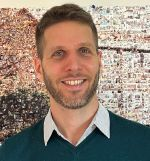

My research revolves around a single object: the **genetic covariance matrix**, which describes how phenotypes co-vary across traits and environments through inheritance, and how individuals resemble each other, whether through pedigree, markers or, more recently, learned representations. I develop **statistical methods** to estimate it when it becomes large and complex, and I use it to understand **how phenotypes are built**: phenotypic plasticity, trade-offs between traits, components of heterosis. This places my work at the interface of quantitative genetics, statistical modeling and machine learning.

## Curriculum

### Main contributions

- **Differentiable REML on GPU.** I developed pyreml, a mixed model library that fits REML by direct differentiation of its loss in `PyTorch`. Running on GPU, it outperforms the state-of-the-art mixed model solver `Wombat` on a dense GBLUP benchmark. Its differentiable design makes it a building block for further developments such as mixed effects neural networks.
- **Factor-analytic mixed models.** With a Master’s student I supervised, I developed a Bayesian implementation of the FA model, then integrated a frequentist version in pyreml: as far as I know, the first open-source REML implementation of the FA mixed model. We illustrated, as a proof of concept, that the kinship can be replaced by a similarity built from neural network embeddings, opening variance decomposition to non-genetic applications (text, images, etc.).
- **Phenotypic plasticity and heterosis.** Using Bayesian random regression along a water-availability gradient, I demonstrated that hybrid larch heterosis, individual genetic contrasts and a growth–density trade-off were all amplified under favorable environmental conditions.
- **Multivariate genetic models.** During my MSc internship, I showed that modeling two correlated yield components jointly improved oil palm selection accuracy, even without the extreme heritability or missing-data patterns usually invoked to justify multivariate models. For hybrid larch, I fitted a 6-trait Bayesian model and characterized the marginal priors induced by parameter expansion, which had not been assessed before.

### Trajectory

After a PhD in quantitative genetics at INRAE-Orléans (2014–2018), I spent ~5 years in the genomic breeding industry and 3 years as a data science consultant. I then returned to academia as a post-doc researcher at [IGMM – CNRS](https://www.igmm.cnrs.fr/en/team/ai-for-genome-interpretation/), where I work on integrating mixed model concepts into neural network models for genomic prediction.

I have taught **700+** hours, starting with science tutoring during my studies (197 hours), then as a teaching assistant at the University of Orléans during my PhD (128 hours), and in professional training (about 378 hours). I have also supervised 4 MSc interns.

### Latest

- **Software, 2026** – [m2n2: mixed modeling with neural networks](https://ai-for-genome-interpretation-lab.github.io/m2n2/)
- **under review** – [pyreml: a general-purpose, GPU-accelerated mixed model solver in Python](https://doi.org/10.64898/2026.10.20.757556)
- **Stat, 2026** – [Bayesian implementation of the factor-analytic mixed model and application to embeddings](https://doi.org/10.1002/sta4.70164)
- **Scientific Reports, 2025** – [Statistical flaws of the fitness-fatigue sports performance prediction model](https://doi.org/10.1038/s41598-025-88153-7)